# SLEEP HEALTH AND LIFESTYLE CLASSIFICATION ANALYSIS

```python
# Import data wrangling software
import numpy as np
import pandas as pd
from pandas import read_csv
```

```python
# Import visualization libraries
import matplotlib.pyplot as plt
import seaborn as sns
```

```python
# Load data set

data = pd.read_csv('Sleep_health_and_lifestyle_dataset.csv')
df = pd.DataFrame(data)
pd.set_option('display.float','{:.2f}'.format)
pd.set_option('display.max_columns',15)
pd.set_option('display.max_rows',10)
pd.set_option('display.width',1000)
```

```python
# import machine learning models
from sklearn.svm import SVC, LinearSVC
from catboost import CatBoostClassifier
from sklearn.linear_model import SGDClassifier
from sklearn.linear_model import LogisticRegression
from sklearn.tree import DecisionTreeClassifier
from sklearn.neighbors import KNeighborsClassifier
from sklearn.discriminant_analysis import LinearDiscriminantAnalysis
from sklearn.naive_bayes import GaussianNB
from sklearn.ensemble import RandomForestClassifier
from sklearn.datasets import make_classification
from sklearn.ensemble import GradientBoostingClassifier
```

```python
from sklearn.model_selection import GridSearchCV, cross_val_score
from sklearn.preprocessing import StandardScaler
from sklearn.decomposition import PCA
from sklearn.model_selection import train_test_split
from sklearn.model_selection import cross_val_score
from sklearn.model_selection import StratifiedKFold
from sklearn.metrics import classification_report
from sklearn.metrics import confusion_matrix
from sklearn.metrics import accuracy_score
from sklearn.preprocessing import StandardScaler
from sklearn.decomposition import PCA
from pandas import read_csv
from pandas.plotting import scatter_matrix
import warnings
warnings.filterwarnings("ignore", category=UserWarning)
```

## EXPLORATORY ANALYSIS

```python
# Data information
df.info()
```

```
<class 'pandas.core.frame.DataFrame'>
RangeIndex: 374 entries, 0 to 373
Data columns (total 13 columns):
 #   Column                   Non-Null Count  Dtype
---  ------                   --------------  -----
 0   Person ID                374 non-null    int64
 1   Gender                   374 non-null    object
 2   Age                      374 non-null    int64
 3   Occupation               374 non-null    object
 4   Sleep Duration           374 non-null    float64
 5   Quality of Sleep         374 non-null    int64
 6   Physical Activity Level  374 non-null    int64
 7   Stress Level             374 non-null    int64
 8   BMI Category             374 non-null    object
 9   Blood Pressure           374 non-null    object
 10  Heart Rate               374 non-null    int64
 11  Daily Steps              374 non-null    int64
 12  Sleep Disorder           374 non-null    object
dtypes: float64(1), int64(7), object(5)
memory usage: 38.1+ KB
```

```python
# Shape of the data set
df.shape
```

```
(374, 13)
```

```python
# Top 5 rows
df.head()
```

|  | Person ID | Gender | Age | Occupation | Sleep Duration | Quality of Sleep | Physical Activity Level | Stress Level | BMI Category | Blood Pressure | Heart Rate | Daily Steps | Sleep Disorder |
| --- | --- | --- | --- | --- | --- | --- | --- | --- | --- | --- | --- | --- | --- |
| 0 | 1 | Male | 27 | Software Engineer | 6.10 | 6 | 42 | 6 | Overweight | 126/83 | 77 | 4200 | None |
| 1 | 2 | Male | 28 | Doctor | 6.20 | 6 | 60 | 8 | Normal | 125/80 | 75 | 10000 | None |
| 2 | 3 | Male | 28 | Doctor | 6.20 | 6 | 60 | 8 | Normal | 125/80 | 75 | 10000 | None |
| 3 | 4 | Male | 28 | Sales Representative | 5.90 | 4 | 30 | 8 | Obese | 140/90 | 85 | 3000 | Sleep Apnea |
| 4 | 5 | Male | 28 | Sales Representative | 5.90 | 4 | 30 | 8 | Obese | 140/90 | 85 | 3000 | Sleep Apnea |

```python
# Bottom 5 rows
df.tail()
```

|  | Person ID | Gender | Age | Occupation | Sleep Duration | Quality of Sleep | Physical Activity Level | Stress Level | BMI Category | Blood Pressure | Heart Rate | Daily Steps | Sleep Disorder |
| --- | --- | --- | --- | --- | --- | --- | --- | --- | --- | --- | --- | --- | --- |
| 369 | 370 | Female | 59 | Nurse | 8.10 | 9 | 75 | 3 | Overweight | 140/95 | 68 | 7000 | Sleep Apnea |
| 370 | 371 | Female | 59 | Nurse | 8.00 | 9 | 75 | 3 | Overweight | 140/95 | 68 | 7000 | Sleep Apnea |
| 371 | 372 | Female | 59 | Nurse | 8.10 | 9 | 75 | 3 | Overweight | 140/95 | 68 | 7000 | Sleep Apnea |
| 372 | 373 | Female | 59 | Nurse | 8.10 | 9 | 75 | 3 | Overweight | 140/95 | 68 | 7000 | Sleep Apnea |
| 373 | 374 | Female | 59 | Nurse | 8.10 | 9 | 75 | 3 | Overweight | 140/95 | 68 | 7000 | Sleep Apnea |

```python
# Check duplicate entry
duplicate = df[df.duplicated('Person ID')]
duplicate
```

|  | Person ID | Gender | Age | Occupation | Sleep Duration | Quality of Sleep | Physical Activity Level | Stress Level | BMI Category | Blood Pressure | Heart Rate | Daily Steps | Sleep Disorder |
| --- | --- | --- | --- | --- | --- | --- | --- | --- | --- | --- | --- | --- | --- |

```python
# Discriptive statistics of numerical data
df.describe()
```

|  | Person ID | Age | Sleep Duration | Quality of Sleep | Physical Activity Level | Stress Level | Heart Rate | Daily Steps |
| --- | --- | --- | --- | --- | --- | --- | --- | --- |
| count | 374.00 | 374.00 | 374.00 | 374.00 | 374.00 | 374.00 | 374.00 | 374.00 |
| mean | 187.50 | 42.18 | 7.13 | 7.31 | 59.17 | 5.39 | 70.17 | 6816.84 |
| std | 108.11 | 8.67 | 0.80 | 1.20 | 20.83 | 1.77 | 4.14 | 1617.92 |
| min | 1.00 | 27.00 | 5.80 | 4.00 | 30.00 | 3.00 | 65.00 | 3000.00 |
| 25% | 94.25 | 35.25 | 6.40 | 6.00 | 45.00 | 4.00 | 68.00 | 5600.00 |
| 50% | 187.50 | 43.00 | 7.20 | 7.00 | 60.00 | 5.00 | 70.00 | 7000.00 |
| 75% | 280.75 | 50.00 | 7.80 | 8.00 | 75.00 | 7.00 | 72.00 | 8000.00 |
| max | 374.00 | 59.00 | 8.50 | 9.00 | 90.00 | 8.00 | 86.00 | 10000.00 |

```python
# Descriptive statistics of categorical variables
df.describe(include=['O'])
```

|  | Gender | Occupation | BMI Category | Blood Pressure | Sleep Disorder |
| --- | --- | --- | --- | --- | --- |
| count | 374 | 374 | 374 | 374 | 374 |
| unique | 2 | 11 | 4 | 25 | 3 |
| top | Male | Nurse | Normal | 130/85 | None |
| freq | 189 | 73 | 195 | 99 | 219 |

```python
# Check for missing data

total_missing = df.isnull().sum().sort_values(ascending = False) # sum of total missing data
sub1 = df.isnull().sum()/df.isnull().count()*100 # percentage of missing data
sub2 = (round(sub1,2).sort_values(ascending = False)) # rounding the missing data

missing_data = pd.concat([total_missing,sub2],axis = 1, keys =['Total','%']) # combine total missing and percentage data in a dataframe
missing_data.head(13)
```

|  | Total | % |
| --- | --- | --- |
| Person ID | 0 | 0.00 |
| Gender | 0 | 0.00 |
| Age | 0 | 0.00 |
| Occupation | 0 | 0.00 |
| Sleep Duration | 0 | 0.00 |
| ... | ... | ... |
| BMI Category | 0 | 0.00 |
| Blood Pressure | 0 | 0.00 |
| Heart Rate | 0 | 0.00 |
| Daily Steps | 0 | 0.00 |
| Sleep Disorder | 0 | 0.00 |

13 rows × 2 columns

No Missing data

```python
# Verify the class variable
df1 = df.groupby('Sleep Disorder').count()
df1
```

| Sleep Disorder | Person ID | Gender | Age | Occupation | Sleep Duration | Quality of Sleep | Physical Activity Level | Stress Level | BMI Category | Blood Pressure | Heart Rate | Daily Steps |
| --- | --- | --- | --- | --- | --- | --- | --- | --- | --- | --- | --- | --- |
| Insomnia | 77 | 77 | 77 | 77 | 77 | 77 | 77 | 77 | 77 | 77 | 77 | 77 |
| None | 219 | 219 | 219 | 219 | 219 | 219 | 219 | 219 | 219 | 219 | 219 | 219 |
| Sleep Apnea | 78 | 78 | 78 | 78 | 78 | 78 | 78 | 78 | 78 | 78 | 78 | 78 |

Three classes with Insomnia 77, None 219 and Sleep Apnea 78.

## DATA VISUALIZATION

```python
# Map the numbers to class variable such as 1,2 and 3 to view correlations with predictors
mapping = {'None':1,'Sleep Apnea':2,'Insomnia':3 }
df['Sleep Disorder'] = df ['Sleep Disorder'].map (mapping)
```

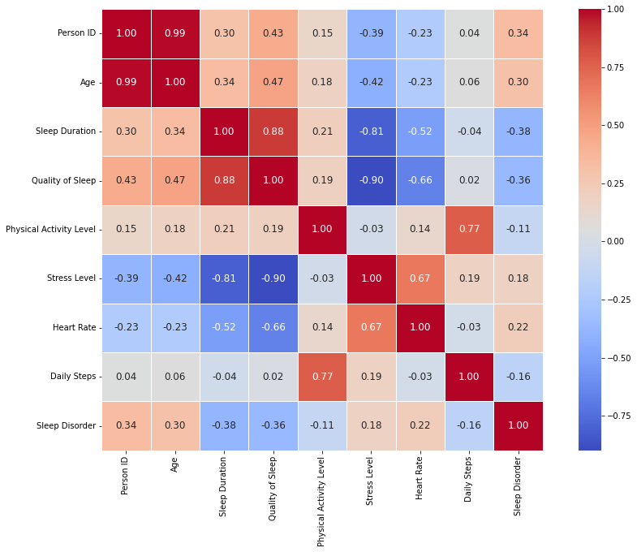

```python
# Creating a heatmap of feature correlation
plt.figure(figsize=(16, 10))
hide = np.tril(df.corr())
sns.heatmap(df.corr(), cmap="coolwarm", annot=True,
            fmt='.2f', annot_kws={'size':12},
            linewidths=0.5, square=True,)
            #mask= hide)
plt.show()
```

Heart Rate Correlations:

Negative Correlations:

Quality of Sleep: There is a strong negative correlation between Stress Level and Quality of Sleep, indicating that higher stress levels are associated with poorer quality of sleep. Age: A negative correlation exists between Age and Stress Level, suggesting that older individuals tend to have lower stress levels.

Quality of Sleep Correlations:

Positive Correlation: Age: A positive correlation between Age and Quality of Sleep indicates that older individuals tend to report better quality of sleep. Negative Correlation: Stress Level: As mentioned, higher stress levels correlate with poorer quality of sleep. Age Correlations:

Negative Correlation: Stress Level: Older age is associated with lower stress levels. Positive Correlation: Quality of Sleep: Older Age is associated with better quality of sleep.

Correlations with Sleep Disorder:

There are slight correlations between the following predictors and the class variable Sleep Disorder: Age: Slight correlation with the likelihood of having a sleep disorder. Quality of Sleep: Slight correlation with sleep disorders.

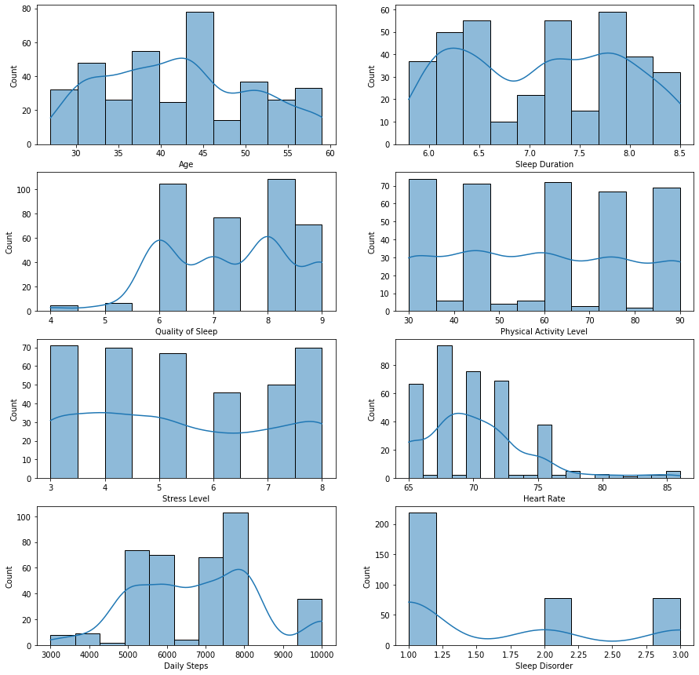

```python
# Data distribution-histplot

plt.figure(figsize=(15,15))
def hist(r,c,n,y):
    plt.subplot(r,c,n)
    sns.histplot(data = df,x=y, kde = True)

hist(4,2,1,'Age')
hist(4,2,2,'Sleep Duration')
hist(4,2,3,'Quality of Sleep')
hist(4,2,4,'Physical Activity Level')
hist(4,2,5,'Stress Level')
hist(4,2,6,'Heart Rate')
hist(4,2,7,'Daily Steps')
hist(4,2,8,'Sleep Disorder')
plt.show()
```

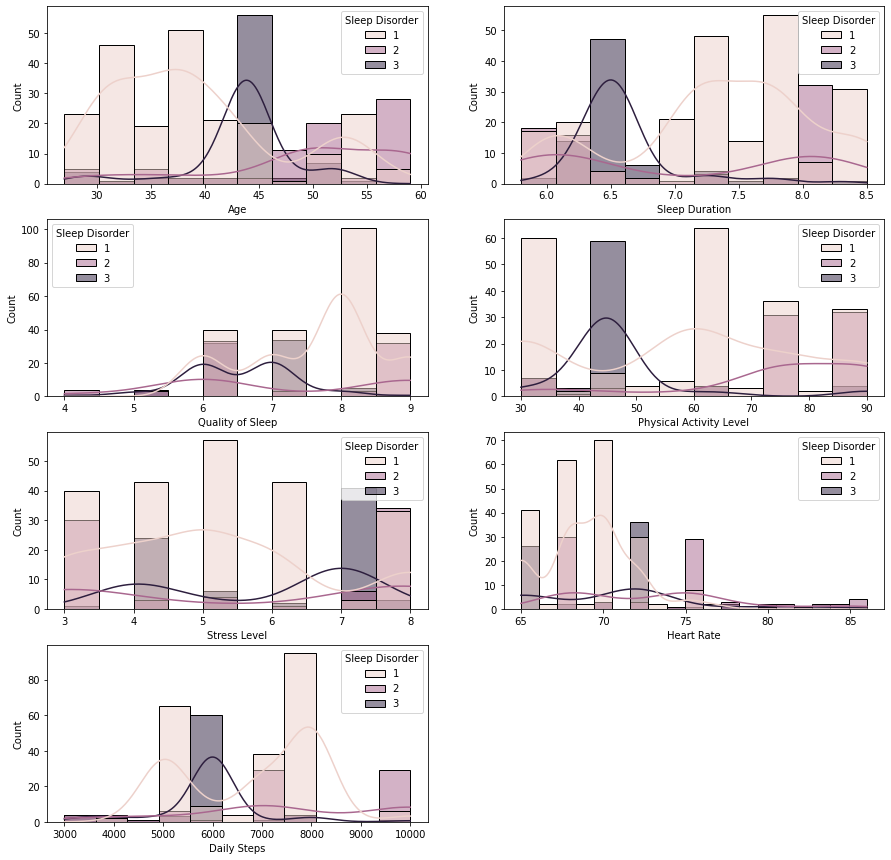

```python
# Data distribution-histplot, groupby class

plt.figure(figsize=(15,15))
def hist(r,c,n,y):
    plt.subplot(r,c,n)
    sns.histplot(data = df,x=y, kde = True, hue ='Sleep Disorder')

hist(4,2,1,'Age')
hist(4,2,2,'Sleep Duration')
hist(4,2,3,'Quality of Sleep')
hist(4,2,4,'Physical Activity Level')
hist(4,2,5,'Stress Level')
hist(4,2,6,'Heart Rate')
hist(4,2,7,'Daily Steps')

plt.show()
```

Variations were observed in different classes compared to each variable.

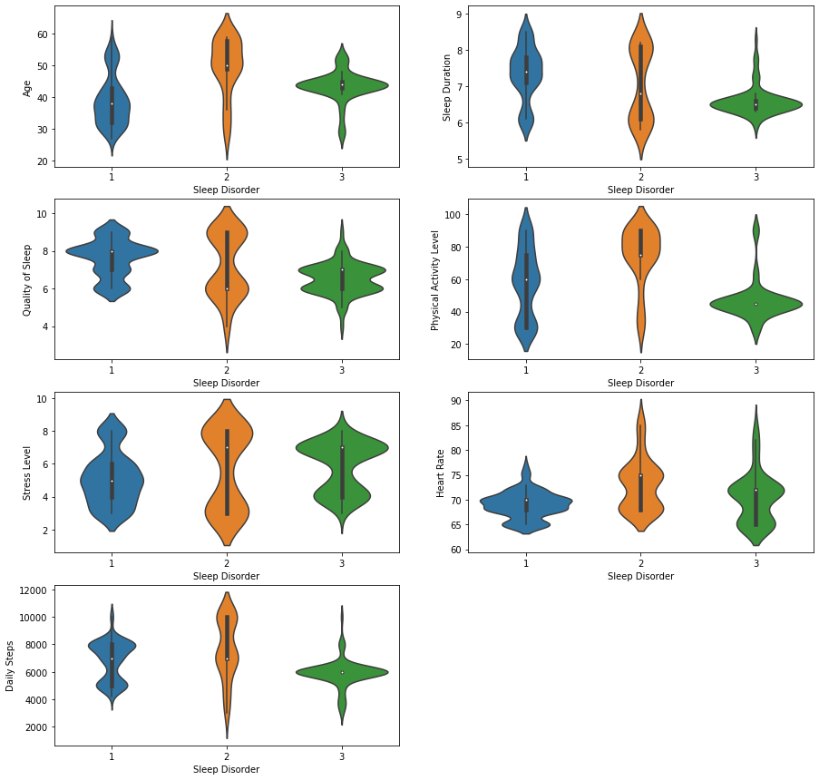

```python
# Data distribution-violin plot, groupby class
plt.figure(figsize = (15,15))
def violin(r, c, n, y):
    plt.subplot(r, c, n)
    sns.violinplot(data=df, y=y, x='Sleep Disorder')

violin(4,2,1,'Age')
violin(4,2,2,'Sleep Duration')
violin(4,2,3,'Quality of Sleep')
violin(4,2,4,'Physical Activity Level')
violin(4,2,5,'Stress Level')
violin(4,2,6,'Heart Rate')
violin(4,2,7,'Daily Steps')
plt.show()
```

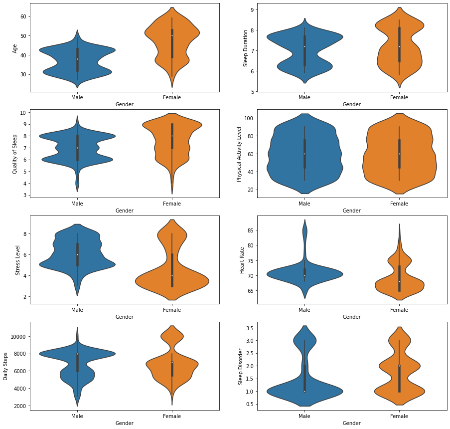

```python
# Data distribution-violin plot, groupby gender
plt.figure(figsize = (15,15))
def violin(r, c, n, y):
    plt.subplot(r, c, n)
    sns.violinplot(data=df, y=y, x='Gender')

violin(4,2,1,'Age')
violin(4,2,2,'Sleep Duration')
violin(4,2,3,'Quality of Sleep')
violin(4,2,4,'Physical Activity Level')
violin(4,2,5,'Stress Level')
violin(4,2,6,'Heart Rate')
violin(4,2,7,'Daily Steps')
violin(4,2,8,'Sleep Disorder')

plt.show()
```

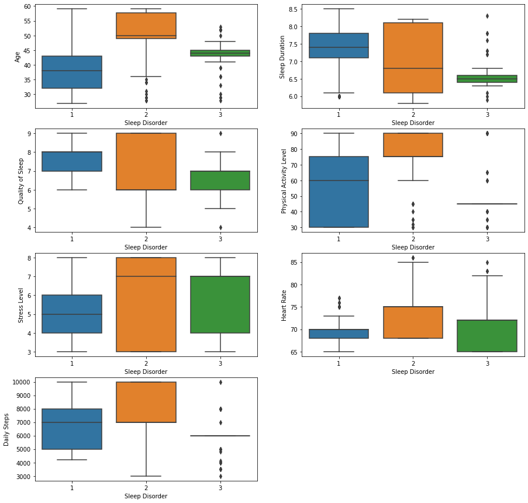

```python
# Data distribution-boxplot, groupby class
plt.figure(figsize = (15,15))
def box(r, c, n, y):
    plt.subplot(r, c, n)
    sns.boxplot(data=df, y=y,x='Sleep Disorder')

box(4,2,1,'Age')
box(4,2,2,'Sleep Duration')
box(4,2,3,'Quality of Sleep')
box(4,2,4,'Physical Activity Level')
box(4,2,5,'Stress Level')
box(4,2,6,'Heart Rate')
box(4,2,7,'Daily Steps')
plt.show()
```

The distribution of Sleep Disorder classes varies across different variables, indicating relationships between them

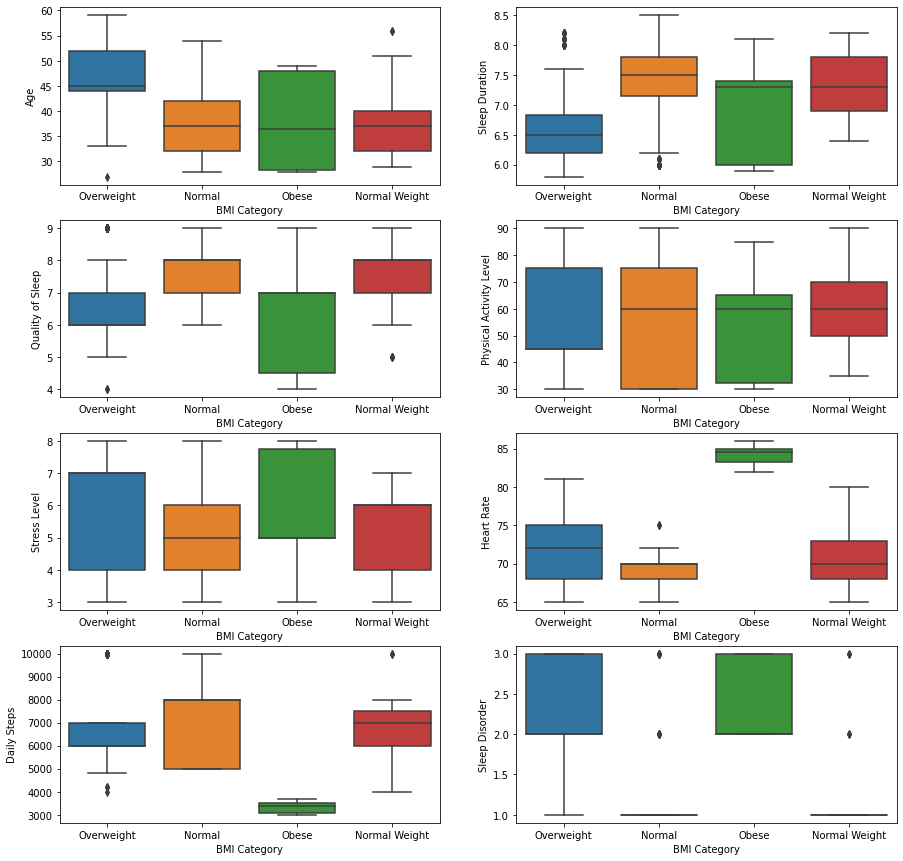

```python
# Data distribution-boxplot, groupby BMI category
plt.figure(figsize = (15,15))
def box(r, c, n, y):
    plt.subplot(r, c, n)
    sns.boxplot(data=df, y=y,x='BMI Category')

box(4,2,1,'Age')
box(4,2,2,'Sleep Duration')
box(4,2,3,'Quality of Sleep')
box(4,2,4,'Physical Activity Level')
box(4,2,5,'Stress Level')
box(4,2,6,'Heart Rate')
box(4,2,7,'Daily Steps')
box(4,2,8,'Sleep Disorder')
plt.show()
```

Relationships were also found between BMI categories and other variables. The median values for Age and Physical Activity Level were approximately the same across BMI categories, except for the overweight category, where notable differences were observed

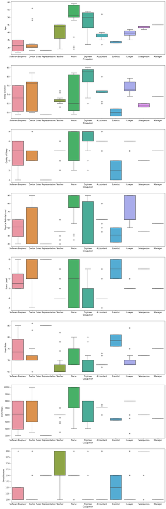

```python
# Data distribution-boxplot, groupby Occupation category
plt.figure(figsize = (15,50))
def box(r, c, n, y):
    plt.subplot(r, c, n)
    sns.boxplot(data=df, y=y,x='Occupation')

box(8,1,1,'Age')
box(8,1,2,'Sleep Duration')
box(8,1,3,'Quality of Sleep')
box(8,1,4,'Physical Activity Level')
box(8,1,5,'Stress Level')
box(8,1,6,'Heart Rate')
box(8,1,7,'Daily Steps')
box(8,1,8,'Sleep Disorder')
plt.show()
```

Significant variations were found among variables across different occupational categories. Approximately no disorders were found among software engineers. However, both Sleep Apnea and Insomnia were found among teachers and salespersons, while Sleep Apnea was observed among scientists.

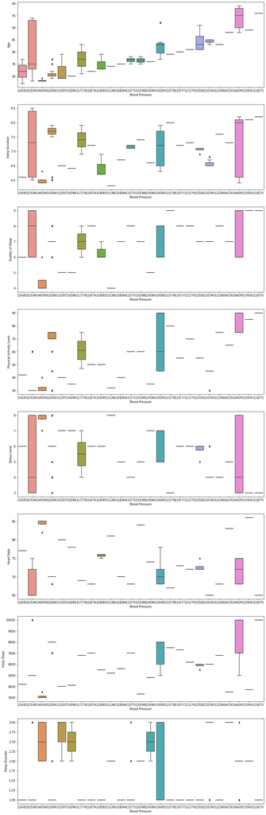

```python
# Data distribution-boxplot, groupby Blood Pressure category
plt.figure(figsize = (15,50))
def box(r, c, n, y):
    plt.subplot(r, c, n)
    sns.boxplot(data=df, y=y,x='Blood Pressure')

box(8,1,1,'Age')
box(8,1,2,'Sleep Duration')
box(8,1,3,'Quality of Sleep')
box(8,1,4,'Physical Activity Level')
box(8,1,5,'Stress Level')
box(8,1,6,'Heart Rate')
box(8,1,7,'Daily Steps')
box(8,1,8,'Sleep Disorder')
plt.show()
```

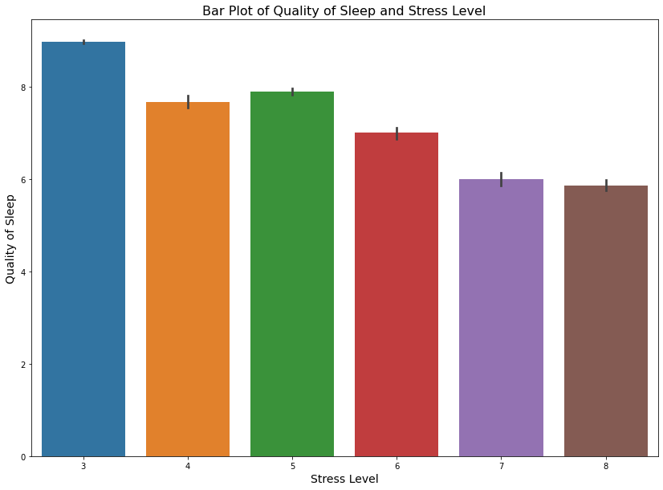

```python
# Bar plot of quality of sleep and stress level
plt.figure(figsize=(14, 10))
sns.barplot(x='Stress Level', y='Quality of Sleep', data=df)

plt.title('Bar Plot of Quality of Sleep and Stress Level', fontsize=16)
plt.xlabel('Stress Level', fontsize=14)
plt.ylabel('Quality of Sleep', fontsize=14)

plt.show()
```

As Stress Level increases, Quality of Sleep decreases.

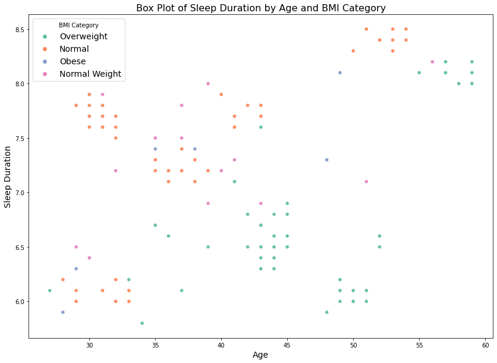

```python
# Analyse with scatter plot for Sleep Duration by Age and BMI Category
plt.figure(figsize=(14, 10))
sns.scatterplot(x='Age', y='Sleep Duration', hue='BMI Category', data=df, palette='Set2')

plt.title('Box Plot of Sleep Duration by Age and BMI Category',fontsize = 16)
plt.xlabel('Age', fontsize = 14)
plt.ylabel('Sleep Duration',fontsize = 14)
plt.legend(title='BMI Category',fontsize = 14)

plt.show()
```

Sleep duration affects all age groups, including those with a normal BMI. However, as age increases, sleep duration improves for individuals with a normal BMI.

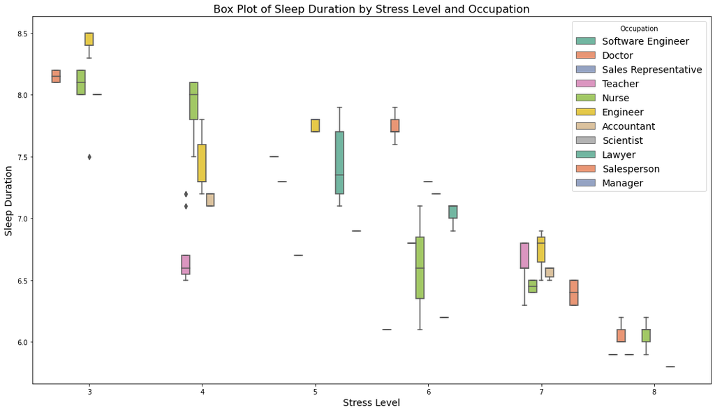

```python
# A closer look with box plot for sleep duration by stress level and occupation
plt.figure(figsize=(18, 10))
sns.boxplot(x='Stress Level', y='Sleep Duration', hue='Occupation', data=df, palette='Set2')

plt.title('Box Plot of Sleep Duration by Stress Level and Occupation',fontsize = 16)
plt.xlabel('Stress Level', fontsize = 14)
plt.ylabel('Sleep Duration',fontsize = 14)
plt.legend(title='Occupation',fontsize = 14)

plt.show()
```

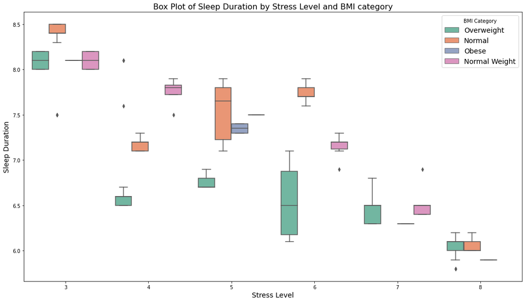

```python
# A closer look  with  box plot for sleep duration by stress level and BMI Category
plt.figure(figsize=(18, 10))
sns.boxplot(x='Stress Level', y='Sleep Duration', hue='BMI Category', data=df, palette='Set2')

plt.title('Box Plot of Sleep Duration by Stress Level and BMI category',fontsize = 16)
plt.xlabel('Stress Level', fontsize = 14)
plt.ylabel('Sleep Duration',fontsize = 14)
plt.legend(title='BMI Category',fontsize = 14)

plt.show()
```

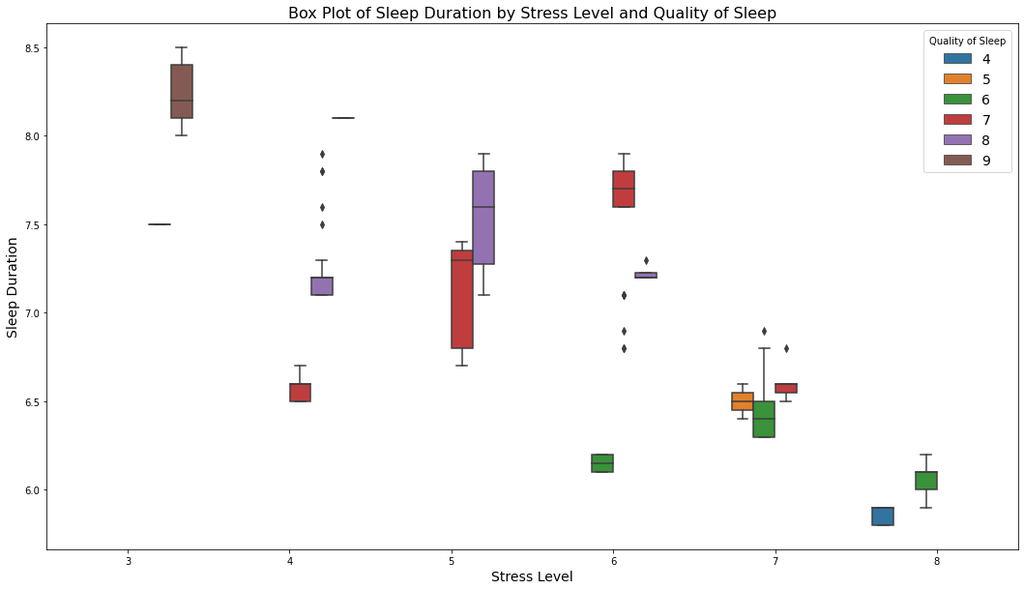

```python
# A close look  with  box plot plot for sleep duration by stress level and quality of sleep
plt.figure(figsize=(18, 10))
sns.boxplot(x='Stress Level', y='Sleep Duration', hue='Quality of Sleep', data=df)

plt.title('Box Plot of Sleep Duration by Stress Level and Quality of Sleep',fontsize = 16)
plt.xlabel('Stress Level', fontsize = 14)
plt.ylabel('Sleep Duration',fontsize = 14)
plt.legend(title='Quality of Sleep',fontsize = 14)

plt.show()
```

# DATA PREPROCESSING

FEATURE ENGINEERING

```python
# Blood pressure column to be split and categorized low values (0) and upper values (1)
df = pd.concat([df, df['Blood Pressure'].str.split('/', expand=True)], axis=1).drop('Blood Pressure', axis=1)
df = df.rename(columns={0: 'BloodPressure_High', 1: 'BloodPressure_Low'})
df['BloodPressure_High'] = df['BloodPressure_High'].astype(float)
df['BloodPressure_Low'] = df['BloodPressure_Low'].astype(float)
```

```python
bp = df[['BloodPressure_High','BloodPressure_Low' ]]
bp
```

|  | BloodPressure_High | BloodPressure_Low |
| --- | --- | --- |
| 0 | 126.00 | 83.00 |
| 1 | 125.00 | 80.00 |
| 2 | 125.00 | 80.00 |
| 3 | 140.00 | 90.00 |
| 4 | 140.00 | 90.00 |
| ... | ... | ... |
| 369 | 140.00 | 95.00 |
| 370 | 140.00 | 95.00 |
| 371 | 140.00 | 95.00 |
| 372 | 140.00 | 95.00 |
| 373 | 140.00 | 95.00 |

374 rows × 2 columns

ONE-HOT ENCODING

```python
# Separate the object type variables
object_vars = df.select_dtypes(include=['object'])
object_vars.columns
```

```
Index(['Gender', 'Occupation', 'BMI Category'], dtype='object')
```

```python
# ONE-HOT Encoding
one_hot_varaible = pd.get_dummies(object_vars, drop_first = True)
```

```python
# Verify one hot vaiable
one_hot_varaible
```

|  | Gender_Male | Occupation_Doctor | Occupation_Engineer | Occupation_Lawyer | Occupation_Manager | Occupation_Nurse | Occupation_Sales Representative | Occupation_Salesperson | Occupation_Scientist | Occupation_Software Engineer | Occupation_Teacher | BMI Category_Normal Weight | BMI Category_Obese | BMI Category_Overweight |
| --- | --- | --- | --- | --- | --- | --- | --- | --- | --- | --- | --- | --- | --- | --- |
| 0 | 1 | 0 | 0 | 0 | 0 | 0 | 0 | 0 | 0 | 1 | 0 | 0 | 0 | 1 |
| 1 | 1 | 1 | 0 | 0 | 0 | 0 | 0 | 0 | 0 | 0 | 0 | 0 | 0 | 0 |
| 2 | 1 | 1 | 0 | 0 | 0 | 0 | 0 | 0 | 0 | 0 | 0 | 0 | 0 | 0 |
| 3 | 1 | 0 | 0 | 0 | 0 | 0 | 1 | 0 | 0 | 0 | 0 | 0 | 1 | 0 |
| 4 | 1 | 0 | 0 | 0 | 0 | 0 | 1 | 0 | 0 | 0 | 0 | 0 | 1 | 0 |
| ... | ... | ... | ... | ... | ... | ... | ... | ... | ... | ... | ... | ... | ... | ... |
| 369 | 0 | 0 | 0 | 0 | 0 | 1 | 0 | 0 | 0 | 0 | 0 | 0 | 0 | 1 |
| 370 | 0 | 0 | 0 | 0 | 0 | 1 | 0 | 0 | 0 | 0 | 0 | 0 | 0 | 1 |
| 371 | 0 | 0 | 0 | 0 | 0 | 1 | 0 | 0 | 0 | 0 | 0 | 0 | 0 | 1 |
| 372 | 0 | 0 | 0 | 0 | 0 | 1 | 0 | 0 | 0 | 0 | 0 | 0 | 0 | 1 |
| 373 | 0 | 0 | 0 | 0 | 0 | 1 | 0 | 0 | 0 | 0 | 0 | 0 | 0 | 1 |

374 rows × 14 columns

```python
#Exclude object data type
numerical_variables = df.select_dtypes(exclude=['object'])
```

```python
# Concatenate the numerical features with the one hot variables
final_data = pd.concat([numerical_variables,one_hot_varaible], axis=1)
```

```python
# Get final data
final_data
```

|  | Person ID | Age | Sleep Duration | Quality of Sleep | Physical Activity Level | Stress Level | Heart Rate | ... | Occupation_Salesperson | Occupation_Scientist | Occupation_Software Engineer | Occupation_Teacher | BMI Category_Normal Weight | BMI Category_Obese | BMI Category_Overweight |
| --- | --- | --- | --- | --- | --- | --- | --- | --- | --- | --- | --- | --- | --- | --- | --- |
| 0 | 1 | 27 | 6.10 | 6 | 42 | 6 | 77 | ... | 0 | 0 | 1 | 0 | 0 | 0 | 1 |
| 1 | 2 | 28 | 6.20 | 6 | 60 | 8 | 75 | ... | 0 | 0 | 0 | 0 | 0 | 0 | 0 |
| 2 | 3 | 28 | 6.20 | 6 | 60 | 8 | 75 | ... | 0 | 0 | 0 | 0 | 0 | 0 | 0 |
| 3 | 4 | 28 | 5.90 | 4 | 30 | 8 | 85 | ... | 0 | 0 | 0 | 0 | 0 | 1 | 0 |
| 4 | 5 | 28 | 5.90 | 4 | 30 | 8 | 85 | ... | 0 | 0 | 0 | 0 | 0 | 1 | 0 |
| ... | ... | ... | ... | ... | ... | ... | ... | ... | ... | ... | ... | ... | ... | ... | ... |
| 369 | 370 | 59 | 8.10 | 9 | 75 | 3 | 68 | ... | 0 | 0 | 0 | 0 | 0 | 0 | 1 |
| 370 | 371 | 59 | 8.00 | 9 | 75 | 3 | 68 | ... | 0 | 0 | 0 | 0 | 0 | 0 | 1 |
| 371 | 372 | 59 | 8.10 | 9 | 75 | 3 | 68 | ... | 0 | 0 | 0 | 0 | 0 | 0 | 1 |
| 372 | 373 | 59 | 8.10 | 9 | 75 | 3 | 68 | ... | 0 | 0 | 0 | 0 | 0 | 0 | 1 |
| 373 | 374 | 59 | 8.10 | 9 | 75 | 3 | 68 | ... | 0 | 0 | 0 | 0 | 0 | 0 | 1 |

374 rows × 25 columns

```python
# Final data info
final_data.info()
```

```
<class 'pandas.core.frame.DataFrame'>
RangeIndex: 374 entries, 0 to 373
Data columns (total 25 columns):
 #   Column                           Non-Null Count  Dtype
---  ------                           --------------  -----
 0   Person ID                        374 non-null    int64
 1   Age                              374 non-null    int64
 2   Sleep Duration                   374 non-null    float64
 3   Quality of Sleep                 374 non-null    int64
 4   Physical Activity Level          374 non-null    int64
 5   Stress Level                     374 non-null    int64
 6   Heart Rate                       374 non-null    int64
 7   Daily Steps                      374 non-null    int64
 8   Sleep Disorder                   374 non-null    int64
 9   BloodPressure_High               374 non-null    float64
```

[output cut: 17 more lines]

```python
# Verify the class variable
df3 = final_data.groupby('Sleep Disorder').count()
df3
```

| Sleep Disorder | Person ID | Age | Sleep Duration | Quality of Sleep | Physical Activity Level | Stress Level | Heart Rate | ... | Occupation_Salesperson | Occupation_Scientist | Occupation_Software Engineer | Occupation_Teacher | BMI Category_Normal Weight | BMI Category_Obese | BMI Category_Overweight |
| --- | --- | --- | --- | --- | --- | --- | --- | --- | --- | --- | --- | --- | --- | --- | --- |
| 1 | 219 | 219 | 219 | 219 | 219 | 219 | 219 | ... | 219 | 219 | 219 | 219 | 219 | 219 | 219 |
| 2 | 78 | 78 | 78 | 78 | 78 | 78 | 78 | ... | 78 | 78 | 78 | 78 | 78 | 78 | 78 |
| 3 | 77 | 77 | 77 | 77 | 77 | 77 | 77 | ... | 77 | 77 | 77 | 77 | 77 | 77 | 77 |

3 rows × 24 columns

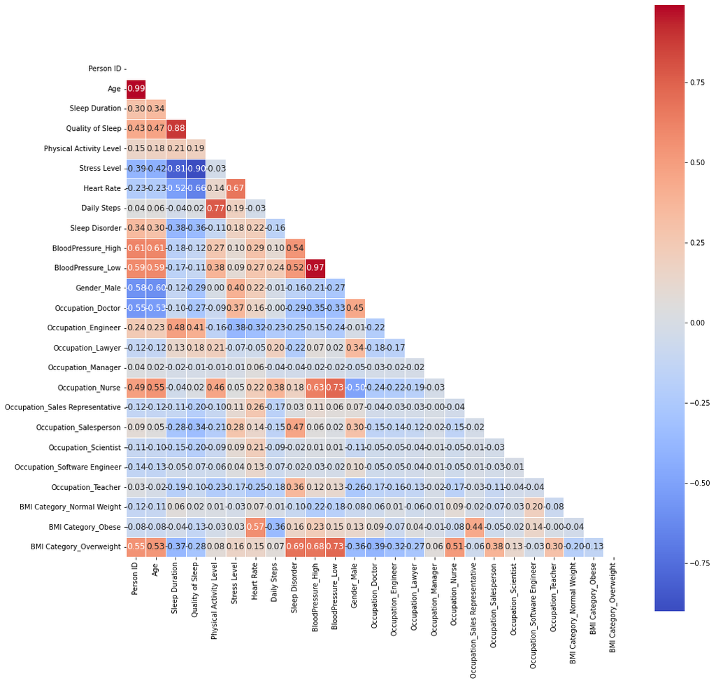

```python
# Creating a heatmap of feature correlation
plt.figure(figsize=(16, 16))
hide = np.triu(final_data.corr())
sns.heatmap(final_data.corr(), cmap="coolwarm", annot=True,
            fmt='.2f', annot_kws={'size':12},
            linewidths=0.5, square=True,
            mask= hide)
plt.show()
```

There are strong positive correlations between High Blood Pressure and Low Blood Pressure, as well as between Daily Steps and Physical Activity Levels.

Additionally, strong negative correlations were observed between Stress Level and both Sleep Duration and Quality of Sleep. Similarly, there is a moderate negative correlation between Heart Rate and both Sleep Duration and Quality of Sleep.

Moreover, moderate positive correlations were noted between Occupation_Nurse and both High Blood Pressure and Low Blood Pressure, as well as between BMI Category_Overweight and both High Blood Pressure and Low Blood Pressure. Furthermore, there is a moderate positive correlation between Heart Rate and BMI Category_Obese.

# MODEL BUILDING

```python
#Assign X anf y variables for model building

X = final_data.drop(columns=['Sleep Disorder','Person ID']) # drop person ID and class variable
y = final_data['Sleep Disorder'].values.reshape(-1, 1)
```

FEATURE SELECTION

```python
#import libraries
from sklearn.feature_selection import SelectKBest
from sklearn.feature_selection import mutual_info_classif

selector = SelectKBest(score_func=mutual_info_classif, k='all') # f_classif to get feature scores
selector.fit(X, y) # fitting with selector

f_scores = selector.scores_ # get feature scores
f_names = X.columns # get feature names

f_scores_df = pd.DataFrame({'Feature': f_names, 'Score': f_scores})# dataframe to store feature name and score
f_scores_df = f_scores_df.sort_values(by='Score', ascending=False) # sort the feature score

f_scores_df # display the feature with scores
```

|  | Feature | Score |
| --- | --- | --- |
| 8 | BloodPressure_Low | 0.50 |
| 7 | BloodPressure_High | 0.47 |
| 1 | Sleep Duration | 0.47 |
| 6 | Daily Steps | 0.46 |
| 0 | Age | 0.45 |
| ... | ... | ... |
| 15 | Occupation_Sales Representative | 0.02 |
| 17 | Occupation_Scientist | 0.00 |
| 18 | Occupation_Software Engineer | 0.00 |
| 20 | BMI Category_Normal Weight | 0.00 |
| 21 | BMI Category_Obese | 0.00 |

23 rows × 2 columns

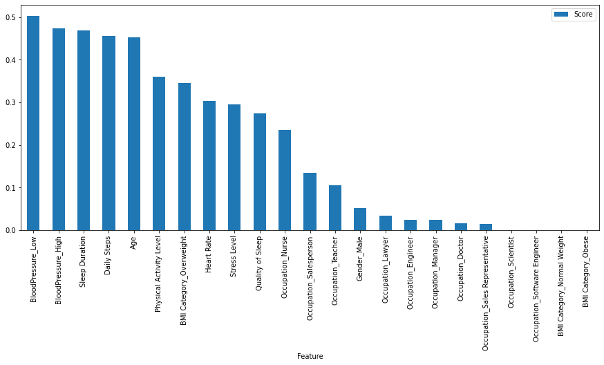

```python
# Plot the best features with higher score

labels = list(set(f_scores_df['Feature']))
fig = plt.figure(figsize=(15, 6))
ax = fig.add_subplot(111)
f_scores_df.plot.bar(x='Feature', y='Score', ax=ax)

plt.show()
```

```python
## Select the top features based on score
select = SelectKBest(score_func=mutual_info_classif, k=12)  # Select top features
select.fit(X, y)

# Get the mask of selected features
feature_mask = select.get_support()

# Get the selected feature names
selected_features = X.columns[feature_mask]

# Create a new DataFrame with the selected features
X_selected = X[selected_features]

# Use X_selected for further analysis and modeling
X_selected
print(X_selected.columns)
```

```
Index(['Age', 'Sleep Duration', 'Quality of Sleep', 'Physical Activity Level', 'Stress Level', 'Heart Rate', 'Daily Steps', 'BloodPressure_High', 'BloodPressure_Low', 'Occupation_Nurse', 'Occupation_Salesperson', 'BMI Category_Overweight'], dtype='object')
```

```python
X = X[X_selected.columns]
```

SPLIT DATA FOR TRAINING AND TESTING

```python
# Split the training data into 80/20 for training and testing. Also ensured stratfication

#X_train,X_test, y_train, y_test = train_test_split(X,y , test_size=0.20, stratify = y,random_state=2)
X_train,X_test, y_train, y_test = train_test_split(X,y , test_size=0.20,random_state=2)
print(X_train.shape)
print(X_test.shape)
print(y_train.shape)
print(y_test.shape)
```

```
(299, 12)
(75, 12)
(299, 1)
(75, 1)
```

```python
# Standardizing the feature to mean 0 and std 1
from sklearn.preprocessing import StandardScaler

scaler = StandardScaler()
X_train = scaler.fit_transform(X_train)
X_test = scaler.transform(X_test)
```

```python
#X-train
mean_train, std_train = np.mean(X_train), np.std(X_train)
print(f"X_train Mean: {mean_train:.1f}, X_train Standard Deviation: {std_train:.0f}")

#X_test
mean_test, std_test = np.mean(X_test), np.std(X_test)
print(f"X_test Mean: {mean_test:.1f}, X_test Standard Deviation: {std_test:.0f}")
```

```
X_train Mean: 0.0, X_train Standard Deviation: 1
X_test Mean: 0.1, X_test Standard Deviation: 1
```

TRAINING

```python
# Load multipple classification models
# Loop over the models and review results

models = []
models.append(('LR', LogisticRegression(solver='liblinear', multi_class='ovr')))
models.append(('LDA', LinearDiscriminantAnalysis()))
models.append(('KNN', KNeighborsClassifier()))
models.append(('CART', DecisionTreeClassifier()))
models.append(('NB', GaussianNB()))
models.append(('SVM', SVC(gamma='auto')))
models.append(('RF',RandomForestClassifier(n_jobs=-1)))
models.append(('CB',CatBoostClassifier(verbose = False)))
models.append (('GB', GradientBoostingClassifier()))


## Evaluate each model in turn
results = [] # print the accuracy score
names = []   # print the model name

for name, model in models: # loop over the models to get the accuracy score of both train and test
    fit = model.fit(X_train, y_train)
    train_predict = model.predict(X_train)
    test_predict = model.predict(X_test)
    accuracy_train = accuracy_score(y_train,train_predict)
    accuracy_test = accuracy_score(y_test,test_predict)

    results.append({
        'Model': name,
        'Score': [accuracy_train, accuracy_test]
    })

result_df = pd.DataFrame(results) # data frame of the results
result_df['Score'] = result_df['Score'].apply(lambda x: ['{:.2f}'.format(score) for score in x]) # round to 2 decimals
result_df = result_df.set_index('Score') # set index as score
result_df = result_df.sort_values(by='Score', ascending=False)

result_df
```

| Score | Model |
| --- | --- |
| [0.93, 0.95] | RF |
| [0.93, 0.95] | CB |
| [0.93, 0.95] | GB |
| [0.93, 0.93] | CART |
| [0.91, 0.93] | SVM |
| [0.91, 0.91] | LR |
| [0.90, 0.92] | LDA |
| [0.90, 0.92] | KNN |
| [0.87, 0.93] | NB |

```python
## K-fold cross validation on training set

results = []

for name, model in models:
    kfold = StratifiedKFold(n_splits=10, random_state=1, shuffle=True)
    cv_results = cross_val_score(model, X_train, y_train, cv=kfold, scoring='accuracy')
    results.append((name, cv_results.mean(), cv_results.std()))

# Sort results by mean accuracy in descending order
results.sort(key=lambda x: x[1], reverse=True)

# Print the sorted results
for name, mean_accuracy, std_dev in results:
    print(f"{name}: {mean_accuracy*100:.2f}% ({std_dev:.3f})")
    print()
```

```
GB: 90.28% (0.039)

CB: 89.92% (0.060)

KNN: 89.28% (0.047)

LR: 89.25% (0.065)

RF: 89.25% (0.053)

LDA: 88.24% (0.072)

SVM: 87.92% (0.060)

CART: 86.91% (0.063)

NB: 85.25% (0.070)
```

HYPER PARAMETER TUNING

RANDOM FOREST

```python
# Hyperparameter Tuning with Randaom forest

param_grid = {
    "min_samples_leaf": [0,1,2],
    "min_samples_split": [1,2,3],
    "n_estimators":np.linspace(0,200,10,dtype=int),
    "max_depth":[None,1,2]
}

#rf = RandomForestClassifier(n_estimators=100, oob_score=True, random_state=42, n_jobs=-1)
#clf = GridSearchCV(estimator=rf, param_grid=param_grid, cv=10, verbose=2, n_jobs=-1)

#clf.fit(X_train, y_train)
#print(clf.best_params_)
```

```python
# Retrain in Random Forest classifier

rf = RandomForestClassifier(
    min_samples_leaf=1,
    min_samples_split=2,
    n_estimators=44,
    oob_score=True,
    max_depth=None,
    random_state=42  # Set random_state for reproducibility
)

# Fit the model on the training data
rf.fit(X_train, y_train)

# Predict on the test data
rf_prediction = rf.predict(X_test)

# Evaluate the model
print(f'Accuracy: {accuracy_score(y_test, rf_prediction):.4f}')
print('Confusion Matrix:')
print(confusion_matrix(y_test, rf_prediction))
print('Classification Report:')
print(classification_report(y_test, rf_prediction))
```

```
Accuracy: 0.9467
Confusion Matrix:
[[42  0  0]
 [ 1 16  1]
 [ 2  0 13]]
Classification Report:
              precision    recall  f1-score   support

           1       0.93      1.00      0.97        42
           2       1.00      0.89      0.94        18
           3       0.93      0.87      0.90        15

    accuracy                           0.95        75
   macro avg       0.95      0.92      0.93        75
weighted avg       0.95      0.95      0.95        75
```

SVM

```python
param_grid = {
    'C': [0.1, 1, 10, 100],
    'gamma': ['scale', 'auto'],
    'kernel': ['linear', 'rbf', 'poly', 'sigmoid']
}

# Step 6: Perform Grid Search
svc = SVC()
grid_search = GridSearchCV(estimator=svc, param_grid=param_grid, cv=5, scoring='accuracy')
grid_search.fit(X_train, y_train)

# Get the best parameters and the best model
best_params = grid_search.best_params_
best_model = grid_search.best_estimator_

#print(f'Best parameters: {best_params}')

# Step 7: Evaluate the best model
#y_pred = best_model.predict(X_test)

#print(f'Accuracy: {accuracy_score(y_test, y_pred):.4f}')
```

```python
# Retrain in scv classifier

svc = SVC(
    C=1,            # Regularization parameter
    gamma='scale',  # Kernel coefficient for 'rbf', 'poly', and 'sigmoid'
    kernel='linear' # Specifies the kernel type
)

# Fit the model on the training data
svc.fit(X_train, y_train)

# Predict on the test data
svc_prediction = svc.predict(X_test)

# Evaluate the model
print(f'Accuracy: {accuracy_score(y_test, svc_prediction):.4f}')
print('Confusion Matrix:')
print(confusion_matrix(y_test, svc_prediction))
print('Classification Report:')
print(classification_report(y_test, svc_prediction))
```

```
Accuracy: 0.9333
Confusion Matrix:
[[42  0  0]
 [ 2 15  1]
 [ 2  0 13]]
Classification Report:
              precision    recall  f1-score   support

           1       0.91      1.00      0.95        42
           2       1.00      0.83      0.91        18
           3       0.93      0.87      0.90        15

    accuracy                           0.93        75
   macro avg       0.95      0.90      0.92        75
weighted avg       0.94      0.93      0.93        75
```

CAT BOOST

```python
param_grid = {
    'iterations': [100, 200, 300],
    'depth': [4, 6, 8],
    'learning_rate': [0.01, 0.1, 0.2],
    'l2_leaf_reg': [1, 3, 5]
}


#cb = CatBoostClassifier( silent=True)
#grid_search = GridSearchCV(estimator=catboost, param_grid=param_grid, cv=5, scoring='accuracy')
#grid_search.fit(X_train, y_train)

# Get the best parameters and the best model
#best_params = grid_search.best_params_
#best_model = grid_search.best_estimator_

#print(f'Best parameters: {best_params}')

# Step 8: Evaluate the best model
#y_pred = best_model.predict(X_test)

#print(f'Accuracy: {accuracy_score(y_test, y_pred):.4f}')
#print('Classification Report:')
#print(classification_report(y_test, y_pred))
```

```python
# Retrian with cat boost classifier

cb = CatBoostClassifier(
    depth=4,            # Depth of trees
    iterations=100,     # Number of iterations
    l2_leaf_reg=12,     # L2 regularization coefficient
    learning_rate=0.2,  # Learning rate
    silent=True         # Silent mode (no output during training)
)

# Fit the model on the training data
cb.fit(X_train, y_train)

# Predict on the test data
cb_prediction = cb.predict(X_test)

# Evaluate the model
print(f'Accuracy: {accuracy_score(y_test, cb_prediction):.4f}')
print('Confusion Matrix:')
print(confusion_matrix(y_test, cb_prediction))
print('Classification Report:')
print(classification_report(y_test, cb_prediction))
```

```
Accuracy: 0.9467
Confusion Matrix:
[[42  0  0]
 [ 1 16  1]
 [ 2  0 13]]
Classification Report:
              precision    recall  f1-score   support

           1       0.93      1.00      0.97        42
           2       1.00      0.89      0.94        18
           3       0.93      0.87      0.90        15

    accuracy                           0.95        75
   macro avg       0.95      0.92      0.93        75
weighted avg       0.95      0.95      0.95        75
```

GRADIENT BOOSTING

```python
param_grid = {
    'n_estimators': [100, 200, 300],
    'learning_rate': [0.01, 0.1, 0.2],
    'max_depth': [3, 4, 5],
    'subsample': [0.7, 0.8, 0.9],
    'min_samples_split': [2, 5, 10],
    'min_samples_leaf': [1, 2, 4]
}

# Step 6: Perform Grid Search
gbc = GradientBoostingClassifier()
grid_search = GridSearchCV(estimator=gbc, param_grid=param_grid, cv=5, scoring='accuracy')
#grid_search.fit(X_train, y_train)

# Get the best parameters and the best model
#best_params = grid_search.best_params_
#best_model = grid_search.best_estimator_

#print(f'Best parameters: {best_params}')

# Step 7: Evaluate the best model
#y_pred = best_model.predict(X_test)

#print(f'Accuracy: {accuracy_score(y_test, y_pred):.4f}')
#print('Classification Report:')
#print(classification_report(y_test, y_pred))
```

Best parameters: {'learning_rate': 0.01, 'max_depth': 3, 'min_samples_leaf': 4, 'min_samples_split': 2, 'n_estimators': 300, 'subsample': 0.8}

```python
# Retrain with gradient booster classifier

gbc = GradientBoostingClassifier(
    learning_rate=0.01,       # Learning rate
    max_depth=3,              # Maximum depth of the individual estimators
    min_samples_leaf=4,       # Minimum number of samples required to be at a leaf node
    min_samples_split=2,      # Minimum number of samples required to split an internal node
    n_estimators=300,         # Number of boosting stages
    subsample=0.8             # Fraction of samples used for fitting the individual base learners
)

# Fit the model on the training data
gbc.fit(X_train, y_train)

# Predict on the test data
gbc_prediction = gbc.predict(X_test)

# Evaluate the model
print(f'Accuracy: {accuracy_score(y_test, gbc_prediction):.4f}')
print('Confusion Matrix:')
print(confusion_matrix(y_test, gbc_prediction))
print('Classification Report:')
print(classification_report(y_test, gbc_prediction))
```

```
Accuracy: 0.9467
Confusion Matrix:
[[42  0  0]
 [ 1 16  1]
 [ 2  0 13]]
Classification Report:
              precision    recall  f1-score   support

           1       0.93      1.00      0.97        42
           2       1.00      0.89      0.94        18
           3       0.93      0.87      0.90        15

    accuracy                           0.95        75
   macro avg       0.95      0.92      0.93        75
weighted avg       0.95      0.95      0.95        75
```

MODEL EVALUATION

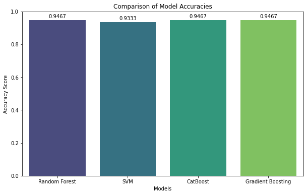

```python
# Model evaluation
rf_accuracy = accuracy_score(y_test, rf_prediction)
svc_accuracy = accuracy_score(y_test, svc_prediction)
cb_accuracy = accuracy_score(y_test, cb_prediction)
gbc_accuracy = accuracy_score(y_test, gbc_prediction)

# accuracy_scores = [rf_accuracy,svc_accuracy,cb_accuracy,gbc_accuracy]
# formatted_scores = ', '.join(f'{score:.4f}' for score in accuracy_scores)
# print(f'accuracy: {formatted_scores}')

accuracy_scores = {
    'Model': ['Random Forest', 'SVM', 'CatBoost', 'Gradient Boosting'],
    'Accuracy': [rf_accuracy, svc_accuracy, cb_accuracy, gbc_accuracy]
}

df_model = pd.DataFrame(accuracy_scores)

# Step 3: Create the bar chart using Seaborn
plt.figure(figsize=(10, 6))
barplot = sns.barplot(x='Model', y='Accuracy', data=df_model, palette='viridis', ci=None)

# Step 4: Add labels to each bar
for index, row in df_model.iterrows():
    barplot.annotate(format(row['Accuracy'], '.4f'),
                     xy=(index, row['Accuracy']),
                     xytext=(0, 3),  # 3 points vertical offset
                     textcoords="offset points",
                     ha='center',
                     va='bottom')

# Step 5: Customize the plot
plt.title('Comparison of Model Accuracies')
plt.xlabel('Models')
plt.ylabel('Accuracy Score')
plt.ylim(0, 1)  # Assuming accuracy scores are between 0 and 1

# Step 6: Display the plot
plt.show()
```

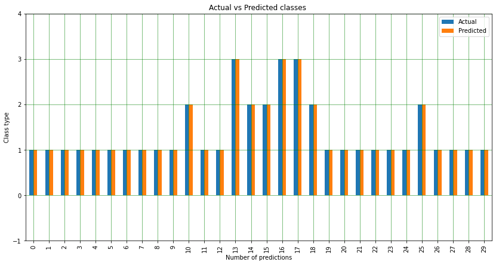

```python
# Comparison between actual and predicted

predicted = rf.predict(X_test)
actual = np.array(list(y_test))
predicted = np.array(list(predicted))

df12 = pd.DataFrame({'Actual': actual.flatten(), 'Predicted': predicted.flatten()})
df12 = df12.round(2)
#print(df12.head(20))

## Create bar graph atual(ytest) vs predicted (yhat)
df20 = df12.head(30)
df20.plot(kind='bar',figsize=(14,7))
#plt = pyplot
plt.title('Actual vs Predicted classes ')
plt.xlabel('Number of predictions')
plt.ylabel('Class type')
plt.ylim(-1, max(max(df20['Actual']), max(df20['Predicted'])) + 1)  # Set y-axis limit to start from -1
plt.grid(which='major', linestyle='-', linewidth='0.5', color='green')
plt.grid(which='minor', linestyle=':', linewidth='0.5', color='black')
plt.show()
```

Compare 30 predicted samples against actual sample classes match 100% perfectly

{1: 'None', 2: 'Sleep Apnea', 3: 'Insomnia'}

ACCURACY

Accuracy is a measure of the overall performance of a classification model. It is calculated as the ratio of correctly predicted instances (sum of true positives and true negatives) to the total number of instances evaluated.

Accuracy: 0.9467 means that the model correctly predicted 94.67% of the samples in the test dataset.

CONFUSION MATRIX

A confusion matrix is a table that summarizes the performance of a classification model. It compares the actual target values with the values predicted by the model.

Class 1 (None):

Class 2 (Sleep Apnea):

Class 3 (Insomnia):

CLASSIFICATION REPORT

A classification report provides a detailed evaluation of the model's performance on each class in the dataset. It includes several metrics:

- **Precision, Recall, F1-score, Support**:
  - *Class 1 (None)*:
    - *Precision*: 0.93 (93% of instances predicted as None were actually None)
    - *Recall*: 1.00 (100% of actual None instances were correctly predicted as None)
    - *F1-score*: 0.97 (balanced measure of precision and recall)
    - *Support*: 42 (number of instances in the test dataset)
  - *Class 2 (Sleep Apnea)*:
    - *Precision*: 1.00 (100% precision indicates no false positives for this class)
    - *Recall*: 0.89 (89% of actual Sleep Apnea instances were correctly predicted)
    - *F1-score*: 0.94 (weighted average of precision and recall)
    - *Support*: 18
  - *Class 3 (Insomnia)*:
    - *Precision*: 0.93 (93% precision indicates few false positives for this class)
    - *Recall*: 0.87 (87% of actual Insomnia instances were correctly predicted)
    - *F1-score*: 0.90 (a measure of a test's accuracy)
    - *Support*: 15

## SUMMARY

The dataset was obtained from Kaggle, a popular platform for datasets and data science competitions.

In the data preprocessing phase, I transformed features into numeric formats, categorized values where necessary, and introduced new features to enhance model performance.

Following preprocessing, I trained nine different machine learning models and selected four for further evaluation. Among them, three models demonstrated similar accuracy and performance metrics. After careful consideration, I chose the random forest model for its robust performance.

Lastly, I evaluated the random forest model using the confusion matrix, precision, recall, and F-score metrics. These evaluations provided comprehensive insights into the model's effectiveness in predicting Sleep Disorders.

Key factors identified as significantly influencing Sleep Disorders include: 'Age', 'Sleep Duration', 'Quality of Sleep', 'Physical Activity Level', 'Stress Level', 'Heart Rate', 'Daily Steps', 'BloodPressure_High', 'BloodPressure_Low', 'Occupation_Nurse', 'Occupation_Salesperson', and 'BMI Category_Overweight'.

This analysis not only highlights the predictive capabilities of the random forest model but also underscores the importance of these factors in understanding and potentially mitigating Sleep Disorders.

ref: https://www.kaggle.com/code/hyungjoon/94-66-acc-eda-ml-comp-sleep-health-data